# Memoria de trabajo

Síntesis, Verificación y Razonamiento sobre Agentes Inteligentes

José Antonio Rodríguez Gallego

17 de febrero de 2022

Se incluye en esta memoria un desglose de los diferentes trabajos realizados para la asignatura *Síntesis, Verificación y Razonamiento sobre Agentes Inteligentes* a lo largo del curso 2021-2022. El contenido aparece dividido por temas, indicando en un primer instante las características de los diferentes elementos que forman las carpetas de trabajo específicas de cada bloque. A continuación, se desarrolla el trabajo realizado, destacando posiblemente algunos puntos de cara a la implementación concreta realizada. Por último, se incluyen algunas posibles mejoras que se podrían llevar a cabo en un futuro.

# Trabajos por tema

En esta sección nos centramos en la creación de un programa que aplique el algoritmo *Value-Iteration*, de una forma tan genérica como me ha resultado posible.

IMPORTANTE

Es necesario crear la carpeta **MDPs** para que “1 - Generador_MDPs.exe” funcione correctamente, si no se ha creado ya.

### Archivos principales

1 - Generador_MDPs.c  
→ Con este documento compilado (.exe) somos capaces de generar multitud de matrices de transición representando MDPs, con cierta personalización sobre el número de nodos.

2 - Representa_MDP.c  
→ Con este documento compilado somos capaces de representar las matrices generadas por el anterior archivo.

3 - Solver_MDPs.c  
→ Con este documento compilado somos capaces de aplicar *Value-Iteration* ante múltiples escenarios: resolución de los elementos de la carpeta MDPS, resolución del problema de Marvin, resolución personalizable de otros problemas concretos.

4 - Marvin el robot.nlogo  
→ Simulación del comportamiento de Marvin el robot, del segundo ejercicio del Capítulo 2.

5 - Marvin el robot con Solver_MDPs  
→ Guía para atacar el problema de Marvin con Solver_MDPs.exe, indicando el lugar en el que se almacenan los resultados.

#### Carpetas

**MDP**

Ejemplos de varias estructuras de datos necesarias para recurrir a las anteriores funcionalidades. Destacamos los elementos Marvin*.txt, necesarios para atacar el problema 2, el de Marvin el robot, con *Value-Iteration*. Se incluye también una referencia de formato.

**MDPS**

Conjunto de matrices asociadas a MDPs, generadas de forma aleatoria según Generador_MDPs.c.

**stats**

Carpeta en la que se almacenan resultados de interés estadístico, tales como el tiempo de ejecución de los diferentes algoritmos.

### Trabajo realizado

Nota

Para ejecutar los archivos .exe es necesario primeramente compilar los documentos .c, y luego lanzar desde la consola de comandos la orden start my_exe.exe. Por comodidad, los .c se encuentran ya compilados con la configuración por defecto.

#### Sobre la generación de las MDPs con 1 - Generador_MDPs.c

Definimos en el documento .c los siguientes parámetros:

| Nombre | Uso |
| --- | --- |
| verbose | Booleano empleado para activar los comentarios adicionales, desactivado por defecto |
| extra_verbose | Semejante al anterior, pero incrementando aún más los comentarios |
| N_max | Tamaño máximo de la matriz de transición asociada al MDP |
| n_max | Máximo número de nodos en el grafo asociado al MDP |

Trabajaremos con la siguiente estructura, que representa una matriz de transición como las vistas en teoría:

```r
  typedef struct transition_matrixes {
    int s_i[N_max]; // Nodo inicial
    int a[N_max]; // Acción a
    int s_j[N_max]; // Nodo de salida
    float p[N_max]; // Probabilidad de llegar al nodo de salida
  } transition_matrix;
```

Para generar la matriz asociada al MDP procedemos en dos pasos. Primeramente incluimos todos los nodos básicos, y los conectamos con otro al azar mediante una acción, la indexada por el 0 en dicho nodo. Como incluiremos más adelante más acciones y posibles salidas para las acciones, en este caso hemos optado por no normalizar la probabilidad $T(s_i, a, s_j)$, dejando dicho paso para más adelante, una vez hayamos fijado todas las acciones y salidas de las mismas.

Una vez creados los nodos básicos entramos en el ciclo de generación de acciones y salidas adicionales, que nos permite comprobar en cada paso si queremos añadir acciones adicionales y, por otro lado, si incluimos una salida adicional para una acción ya definida. Nótese que debido a la forma en la que hemos escrito se produce una cierta tendencia hacia MDPs con un par de acciones con varias salidas, y a lo más una o dos más acciones adicionales. Este comportamiento podría personalziarse sin mucha dificultad controlando la función probability_evolution. Incluimos a continuación el pseudocódigo asociado a dicho algoritmo:

```r
  new_action <- 0
  for (node in nodes) {
    another_action <- rand_num < base_p_another_action;
    another_exit <- rand_num < base_p_another_exit;
    while (another_action || another_action || new_action) {
      let a one-of actions of node;

      if (another_exit || new_action) {
        create T[N];
        N++;

        another_exit_p <- probability_evolution(another_exit_p, 0);
                another_exit <- rand_num < another_exit_p;
      }

      if (another_action) {
        new_action <- 1;
        crete T[N];
        N++;
                another_action_p <- probability_evolution(another_action_p, 0);
              another_action <- rand_num < another_action_p;
      } else {
        new_action <- 0;
      }
    }
  }
```

donde $T$ es la matriz de transición que estamos generando, con $N-1$ la última fila declarada, y *probability_evolution* es una función que determina la evolución de la probabilidad base de incluir una nueva salida o acción, en nuestro caso:
$$probability\_evolution(x) = \frac{x}{2}$$
. El segundo argumento admite distinción entre acciones y salidas, pero no ha llegado a ser usado.

A continuación garantizamos la conexión del grafo generado, representado por la matriz $T$, recurriendo al siguiente algoritmo voraz:

```r
        int visited_node[n]; // Guardaremos aquí, para cada nodo, si está conectado con el nodo i en el que nos centramos
        int unvisited; // Nodo desconectado
        int from_node; // Nodo con el que lo conectaremos

        for (i in nodes) {
          visited_node[i] <- 1;
          for (j in nodes) {
            if (node != i) {
                    visited_node[node] <- 0; // Los otros aún no han sido visitados
                }
          }
        }

        for (rep = 0; rep < n; rep++) {
            for (node in nodes) {
                if (visited_node[node]) {
                    for (j row of T) { // Recorremos T buscando conexiones con node
                        if (T.s_i[j] == node) {
                            visited_node[T.s_j[j]] <- 1; // Y añadimos aquellos que estamos visitando partiendo de i
                        }
                    }
                }
            }
        }

        do {
            // Buscamos uno desconectado (no visitado), que guardaremos en unvisited
            for (node in nodes) {
                if (!visited_node[node]) {
                    unvisited <- node;

                    do {
                        from_node <- rand_node;
                    } while (!visited_node[from_node]);

                    create T[N] with (from_node, random_action, unvisited, random_probabilty);
                    N++;

                    visited_node[unvisited] <- 1;

                    break;
                }

                if (node == n-1) {
                    unvisited <- -1;
                }
            }
        } while (unvisited != -1);
    }
```

Una vez hemos creado la matriz $T$ en la que nos hemos centrado en este paso, eliminamos los duplicados generados con la creación de acciones básicas o con el fragmento en el que se garantiza la conexión del grafo. A continuación, normalizamos las probabilidades para cada combinación de nodo-acción, la imprimimos por pantalla y la guardamos en un fichero random_mat_n.txt, con $n \in [0, 999]$.

#### Ejemplo de ejecución de 1 - Generador_MDPs.c

```r
Cuántas matrices desea crear? (n<=1000)
1
Desea que las matrices tengan el número prefijado de nodos (6), uno escogido (n>1) o uno al azar dada una cota superior? (1, 2, 3)
2
Elija el número prefijado o la cota para el número de nodos (n<=30):
15
n = 15
s_i     a       s_j     T (p)
0       0       6       1.000000
1       0       2       1.000000
2       0       7       0.141654
3       0       11      1.000000
4       0       8       0.560078
5       0       7       0.311300
6       0       10      1.000000
7       0       12      0.298033
8       0       14      1.000000
12      0       0       0.423524
10      0       9       1.000000
11      0       2       1.000000
12      0       2       0.465539
13      0       14      1.000000
14      0       12      1.000000
0       1       13      0.501930
0       1       8       0.498070
2       0       11      0.858346
3       1       9       0.578576
3       1       10      0.421424
4       0       3       0.439922
4       1       4       0.721677
4       1       14      0.278323
5       0       3       0.007857
5       1       1       1.000000
5       0       6       0.325491
5       2       11      1.000000
5       0       13      0.355352
7       1       14      1.000000
7       0       3       0.701967
7       2       1       0.861805
7       2       11      0.138195
8       1       5       0.528081
8       1       7       0.471919
14      1       8       0.358162
9       1       5       1.000000
9       0       13      1.000000
10      1       12      0.531018
10      1       4       0.468982
11      1       13      0.761057
11      1       10      0.238943
12      0       11      0.110937
14      1       1       0.641838

MDPs/random_mat_000.txt

================================================================
================================================================
```

#### Ejemplo de ejecución de 2 - Representa_MDPs.c

En el siguiente fichero, 2 - Representa_MDPs.c, se incluye una herramienta que, si bien rudimentaria, nos permite visualizar el MDP generado. Un ejemplo de salida sería la siguiente:

```r
Desea usar el "default display"? (1 ó 0)
Partimos de la siguiente estructura de datos:
Escriba la dirección del MDP, o 1 si desea usar una predefinida:
1
Usando dirección por defecto: MDP/MDP_1.txtLectura de la matriz:
Estructura de la matriz:
s_i     a       s_j     T (p)
1       1       1       0.200000
1       1       2       0.800000
1       2       1       0.200000
1       2       4       0.800000

s_i     r
0       1.000000
1       3.000000
2       5.000000
3       9.000000


s_i: 0

s_i: 1
|
|
|       a:1     p:0.200000
\----------------------------------> s_j: 1
|
|
|       a:1     p:0.800000
\----------------------------------> s_j: 2
|
|
|       a:2     p:0.200000
\----------------------------------> s_j: 1
|
|
|       a:2     p:0.800000
\----------------------------------> s_j: 4

s_i: 2

s_i: 3
```

Una vez hemos sido capaces de construir matrices de transición asociadas a MDPs, el siguiente paso es aplicar el algoritmo *Value-Iteration*, tal y como se hace en 3 - Solver_MDPs.c. Nuevamente trabajamos con los parámetros *verbose, N_max* y *n_max*, con el mismo significado que antes. En este caso establecemos *verbose <- 0* por defecto para facilitar la visualización de las salidas obtenidas.

```r
# Descripción del algoritmo del capítulo 2
VALUE-ITERATION(T,r,γ,ε)
 u = 0 (la función nula)
 Hacer:
 │  u = u'
 │  Para cada s ∈ S hacer:
 │      u'(s) = r(s) + γ max_a Σ_{s'}T(s,a,s')u(s')
 │  δ = max_s |u'(s)-u(s)|
 └ mientras δ > ε(1-γ)/γ
 Devolver u
```

Destacamos que la mayor dificultad del código es, con diferencia, el cálculo de $u'$ en cada iteración, obligándonos a definir una función independiente, max_a, para calcular el máximo indicado por el algoritmo.

Además, incluimos en la ejecución la posibilidad de trabajar con una matriz de transición y/o de recompensas concretas, o bien con recompensas aleatorias, incluyendo también la opción de aplicar el algoritmo a todas las matrices generadas con el programa anterior, que es justamente lo que haremos para obtener información sobre le rendimiento del programa.

Por último, se incluyen parámetros relativos a la representación gráfica, llamando a una función análoga a la definida en 2 - Representa_MDP.c, y también se le da al usuario la opción de guardar la información generada en un fichero concreto.

#### Ejemplo de ejecución de 3 - Solver_MDPs.c

```r
===============================================
Accediendo al fichero MDPs/random_mat_001.txt
Generando matriz de recompensas aleatorias
--------------------------------------------
Arrancamos el algoritmo Value-Iteration.

s       u               u'
0       0.000000        14.000000
1       0.000000        49.000000
2       0.000000        3.000000
3       0.000000        45.000000
4       0.000000        12.000000
5       0.000000        17.000000
6       0.000000        43.000000
7       0.000000        14.000000
8       0.000000        28.000000
9       0.000000        12.000000
10      0.000000        16.000000
11      0.000000        7.000000
12      0.000000        9.000000
13      0.000000        31.000000
14      0.000000        46.000000

s       u               u'
0       14.000000       18.561562
1       49.000000       50.495129
2       3.000000        4.400000
3       45.000000       49.900002
4       12.000000       16.465553
5       17.000000       20.058256
6       43.000000       47.599998
7       14.000000       15.152040
8       28.000000       30.841627
9       12.000000       16.500000
10      16.000000       20.368544
11      7.000000        8.982529
12      9.000000        10.437696
13      31.000000       35.600002
14      46.000000       47.569237

s       u               u'
0       18.561562       18.846516
1       50.495129       50.856155
2       4.400000        4.515204
3       49.900002       50.049515
4       16.465553       16.758303
5       20.058256       20.348076
6       47.599998       47.756924
7       15.152040       15.582260
8       30.841627       31.311527
9       16.500000       16.990000
10      20.368544       20.838823
11      8.982529        9.274031
12      10.437696       10.716402
13      35.600002       35.846867
14      47.569237       47.956619

s_i     u
0       18.846516
1       50.856155
2       4.515204
3       50.049515
4       16.758303
5       20.348076
6       47.756924
7       15.582260
8       31.311527
9       16.990000
10      20.838823
11      9.274031
12      10.716402
13      35.846867
14      47.956619

time_spent=0.024000''
```

**Nota**: Se empieza a plantear el algoritmo *Q-Learning*, dejando los fragmentos del código donde este se ejecutaría, así como las estructuras correspondientes.

Podemos ahora aplicar el programa generado a otro ejercicio, [el de Marvin](https://www.cs.us.es/~fsancho/Cursos/SVRAI/ejercicios.md.html#tema2:agentesbasadosenutilidades):

Marvin es un robot que habita en una cuadrícula de 3×3 y sólo puede moverse hacia el Norte, Sur, Este y Oeste. Las ruedas de Marvin giran a veces, de modo que en cada acción hay una probabilidad de 0,2 de que Marvin permanezca inmóvil. Marvin recibe una recompensa de 1 cada vez que visita la casilla central:  
1. Dibuja un MDP que describa el problema de Marvin.  
2. ¿Cuál es la política óptima?

Primeramente implementamos en NetLogo el movimiento de Marvin, suponiendo que tiene que moverse en cada paso y que escoge aleatoriamente hacia dónde desplazarse.

#### Visualización de 4 - Marvin el robot.nlogo

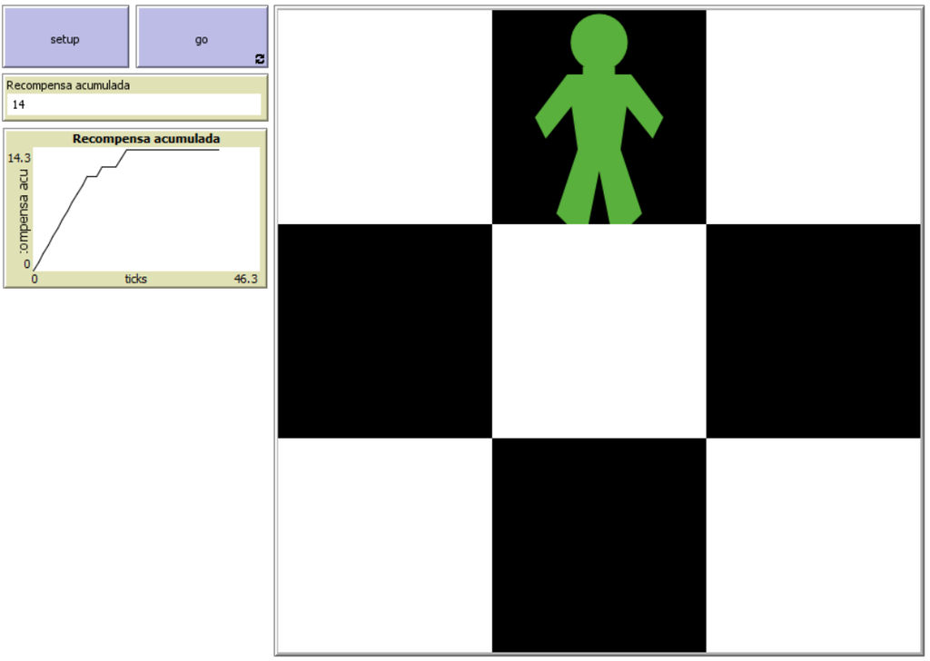

Ahora bien, para poder aplicar el programa desarrollado es necesario disponer de la matriz de transición asociada a este problema. Aunque para un problema mayor esto sería impracticable, en este caso hemos definido la matriz manualmente, al haber solo 9 nodos. Análogamente, es necesario también definir la matriz de recompensas, tarea en este caso sencilla.

La matriz de transición asociada al problema se encuentra en MDP/Marvin.txt, y en Marvin_r.txt podemos ver la matriz de recompensas asociada. Incluimos aquí la representación de las 2 por comodidad:

| $s_i$ | $a$ | $s_j$ | $T(s_i, a, s_j)$ |
| --- | --- | --- | --- |
| 0 | 0 | 1 | 0.8 |
| 0 | 0 | 0 | 0.2 |
| 0 | 1 | 3 | 0.8 |
| 0 | 1 | 0 | 0.2 |
| 1 | 0 | 0 | 0.8 |
| 1 | 0 | 1 | 0.2 |
| 1 | 1 | 4 | 0.8 |
| 1 | 1 | 1 | 0.2 |
| 1 | 2 | 2 | 0.8 |
| 1 | 2 | 1 | 0.2 |
| 2 | 0 | 1 | 0.8 |
| 2 | 0 | 2 | 0.2 |
| 2 | 1 | 5 | 0.8 |
| 2 | 1 | 2 | 0.2 |
| 3 | 0 | 0 | 0.8 |
| 3 | 0 | 3 | 0.2 |
| 3 | 1 | 4 | 0.8 |
| 3 | 1 | 3 | 0.2 |
| 3 | 2 | 6 | 0.8 |
| 3 | 2 | 3 | 0.2 |
| 4 | 0 | 1 | 0.8 |
| 4 | 0 | 4 | 0.2 |
| 4 | 1 | 3 | 0.8 |
| 4 | 1 | 4 | 0.2 |
| 4 | 2 | 5 | 0.8 |
| 4 | 2 | 4 | 0.2 |
| 4 | 3 | 7 | 0.8 |
| 4 | 3 | 4 | 0.2 |
| 5 | 0 | 2 | 0.8 |
| 5 | 0 | 5 | 0.2 |
| 5 | 1 | 4 | 0.8 |
| 5 | 1 | 5 | 0.2 |
| 5 | 2 | 8 | 0.8 |
| 5 | 2 | 5 | 0.2 |
| 6 | 0 | 3 | 0.8 |
| 6 | 0 | 6 | 0.2 |
| 6 | 1 | 7 | 0.8 |
| 6 | 1 | 6 | 0.2 |
| 7 | 0 | 6 | 0.8 |
| 7 | 0 | 7 | 0.2 |
| 7 | 1 | 4 | 0.8 |
| 7 | 1 | 7 | 0.2 |
| 7 | 2 | 8 | 0.8 |
| 7 | 2 | 7 | 0.2 |
| 8 | 0 | 7 | 0.8 |
| 8 | 0 | 8 | 0.2 |
| 8 | 1 | 5 | 0.8 |
| 8 | 1 | 8 | 0.2 |

| $s_i$ | $r$ |
| --- | --- |
| 0 | 0 |
| 1 | 0 |
| 2 | 0 |
| 3 | 0 |
| 4 | 1 |
| 5 | 0 |
| 6 | 0 |
| 7 | 0 |
| 8 | 0 |

Recurriendo al programa ya descrito con estos parámetros obtenemos el siguiente resultado, guardado en MDP/Marvin_Res.txt:

#### Ejemplo de ejecución de 3 - Solver_MDPs.c con el problema de Marvin

```r
N = 48, n = 9
========================================================================================
Matriz de transici¢n T
s_i a   s_j T (p)
0   0   1   0.800000
0   0   0   0.200000
0   1   3   0.800000
0   1   0   0.200000
1   0   0   0.800000
1   0   1   0.200000
1   1   4   0.800000
1   1   1   0.200000
1   2   2   0.800000
1   2   1   0.200000
2   0   1   0.800000
2   0   2   0.200000
2   1   5   0.800000
2   1   2   0.200000
3   0   0   0.800000
3   0   3   0.200000
3   1   4   0.800000
3   1   3   0.200000
3   2   6   0.800000
3   2   3   0.200000
4   0   1   0.800000
4   0   4   0.200000
4   1   3   0.800000
4   1   4   0.200000
4   2   5   0.800000
4   2   4   0.200000
4   3   7   0.800000
4   3   4   0.200000
5   0   2   0.800000
5   0   5   0.200000
5   1   4   0.800000
5   1   5   0.200000
5   2   8   0.800000
5   2   5   0.200000
6   0   3   0.800000
6   0   6   0.200000
6   1   7   0.800000
6   1   6   0.200000
7   0   6   0.800000
7   0   7   0.200000
7   1   4   0.800000
7   1   7   0.200000
7   2   8   0.800000
7   2   7   0.200000
8   0   7   0.800000
8   0   8   0.200000
8   1   5   0.800000
8   1   8   0.200000

========================================================================================
Matriz de recompensas T
s_i r
0   0.000000
1   0.000000
2   0.000000
3   0.000000
4   1.000000
5   0.000000
6   0.000000
7   0.000000
8   0.000000

========================================================================================
Grafo asociado a T

s_i: 0
|
|
|   a:0 p:0.800000
\----------------------------------> s_j: 1
|
|
|   a:0 p:0.200000
\----------------------------------> s_j: 0
|
|
|   a:1 p:0.800000
\----------------------------------> s_j: 3
|
|
|   a:1 p:0.200000
\----------------------------------> s_j: 0

s_i: 1
|
|
|   a:0 p:0.800000
\----------------------------------> s_j: 0
|
|
|   a:0 p:0.200000
\----------------------------------> s_j: 1
|
|
|   a:1 p:0.800000
\----------------------------------> s_j: 4
|
|
|   a:1 p:0.200000
\----------------------------------> s_j: 1
|
|
|   a:2 p:0.800000
\----------------------------------> s_j: 2
|
|
|   a:2 p:0.200000
\----------------------------------> s_j: 1

s_i: 2
|
|
|   a:0 p:0.800000
\----------------------------------> s_j: 1
|
|
|   a:0 p:0.200000
\----------------------------------> s_j: 2
|
|
|   a:1 p:0.800000
\----------------------------------> s_j: 5
|
|
|   a:1 p:0.200000
\----------------------------------> s_j: 2

s_i: 3
|
|
|   a:0 p:0.800000
\----------------------------------> s_j: 0
|
|
|   a:0 p:0.200000
\----------------------------------> s_j: 3
|
|
|   a:1 p:0.800000
\----------------------------------> s_j: 4
|
|
|   a:1 p:0.200000
\----------------------------------> s_j: 3
|
|
|   a:2 p:0.800000
\----------------------------------> s_j: 6
|
|
|   a:2 p:0.200000
\----------------------------------> s_j: 3

s_i: 4
|
|
|   a:0 p:0.800000
\----------------------------------> s_j: 1
|
|
|   a:0 p:0.200000
\----------------------------------> s_j: 4
|
|
|   a:1 p:0.800000
\----------------------------------> s_j: 3
|
|
|   a:1 p:0.200000
\----------------------------------> s_j: 4
|
|
|   a:2 p:0.800000
\----------------------------------> s_j: 5
|
|
|   a:2 p:0.200000
\----------------------------------> s_j: 4
|
|
|   a:3 p:0.800000
\----------------------------------> s_j: 7
|
|
|   a:3 p:0.200000
\----------------------------------> s_j: 4

s_i: 5
|
|
|   a:0 p:0.800000
\----------------------------------> s_j: 2
|
|
|   a:0 p:0.200000
\----------------------------------> s_j: 5
|
|
|   a:1 p:0.800000
\----------------------------------> s_j: 4
|
|
|   a:1 p:0.200000
\----------------------------------> s_j: 5
|
|
|   a:2 p:0.800000
\----------------------------------> s_j: 8
|
|
|   a:2 p:0.200000
\----------------------------------> s_j: 5

s_i: 6
|
|
|   a:0 p:0.800000
\----------------------------------> s_j: 3
|
|
|   a:0 p:0.200000
\----------------------------------> s_j: 6
|
|
|   a:1 p:0.800000
\----------------------------------> s_j: 7
|
|
|   a:1 p:0.200000
\----------------------------------> s_j: 6

s_i: 7
|
|
|   a:0 p:0.800000
\----------------------------------> s_j: 6
|
|
|   a:0 p:0.200000
\----------------------------------> s_j: 7
|
|
|   a:1 p:0.800000
\----------------------------------> s_j: 4
|
|
|   a:1 p:0.200000
\----------------------------------> s_j: 7
|
|
|   a:2 p:0.800000
\----------------------------------> s_j: 8
|
|
|   a:2 p:0.200000
\----------------------------------> s_j: 7

s_i: 8
|
|
|   a:0 p:0.800000
\----------------------------------> s_j: 7
|
|
|   a:0 p:0.200000
\----------------------------------> s_j: 8
|
|
|   a:1 p:0.800000
\----------------------------------> s_j: 5
|
|
|   a:1 p:0.200000
\----------------------------------> s_j: 8

========================================================================================
Resultados de Value-Iteration
gamma = 0.100000, eps = 0.010000
s_i u
0   0.000000
1   0.080000
2   0.000000
3   0.080000
4   1.020000
5   0.080000
6   0.000000
7   0.080000
8   0.000000
```

Con esto nos está indicando que el nodo con la mayor utilidad es el número 4, el central, tal y como era esperable, y que los otros nodos más útiles son aquellos adyacentes a él, según las cuatro direcciones cardinales: los nodos 1, 3, 5 y 7. Por lo tanto, la política obtenida es aquella en la que, en cada paso, centramos nuestro esfuerzo en llegar al centro (4) si estamos adyacentes a él, o bien a una de las casillas adyacentes (1, 3, 5, 7), sin darle preferencia a ninguna en particular.

### Análisis estadístico de los resultados

Incluimos en esta sección una pequeña discusión de algunos de los resultados obtenidos, especialmente aquellos referidos a la eficiencia del algoritmo definido.

Recordemos que la salida esperada del “solver” tiene el siguiente formato:

| n | time_spent | method | gamma | eps |
| --- | --- | --- | --- | --- |
| 5 | 0.009000 | VI | 0.100000 | 0.010000 |
| 4 | 0.028000 | VI | 0.100000 | 0.010000 |
| 19 | 0.076000 | VI | 0.100000 | 0.010000 |

escrito como texto plano en el documento “\Tema 2 - MDPs\stats\MDP_sample.txt”.

Nota: *VI* se refiere a *Value-Iteration*, pues la plantilla estaba preparada para incluir otros algoritmos, concretamente el de *Q-Learning*.

Presentamos primeramente algunos gráficos con los resultados obtenidos. Recurrimos al paquete ggplot2 para ello, si bien primero añadimos una columna adicional, *low*, para indicar si $time\_spent < 0.1$, pues como veremos a continuación existe una tendencia general en *time_spent*, tomando valores menores que dicha cota.

| n_nodes | time_spent | method | gamma | eps | low |
| --- | --- | --- | --- | --- | --- |
| 27 | 0.328 | VI | 0.1 | 0.01 | FALSE |
| 15 | 0.184 | VI | 0.1 | 0.01 | FALSE |
| 18 | 0.240 | VI | 0.1 | 0.01 | FALSE |
| 10 | 0.136 | VI | 0.1 | 0.01 | FALSE |
| 14 | 0.200 | VI | 0.1 | 0.01 | FALSE |
| 11 | 0.192 | VI | 0.1 | 0.01 | FALSE |

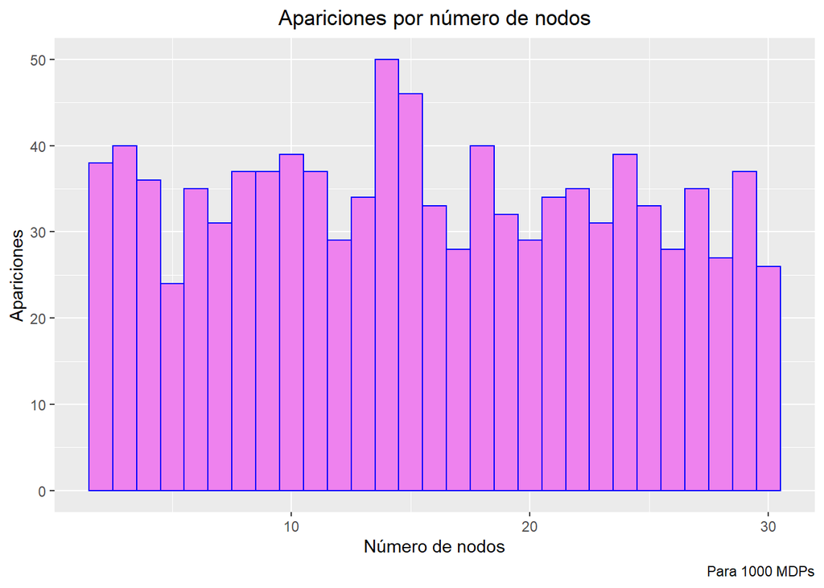

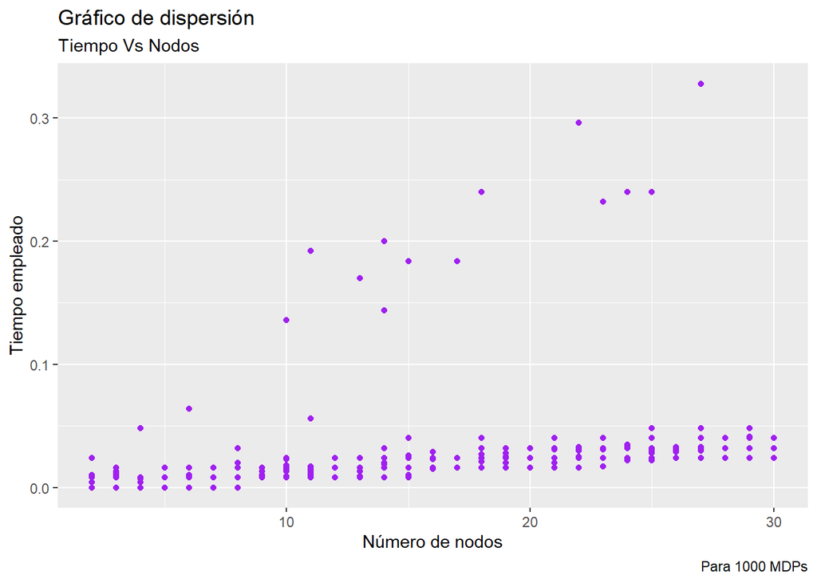

Resulta llamativo ver que, en general, el algoritmo emplea una cantidad reducida de tiempo, inferior a 0.1 segundos, en aplicar *Value-Iteration* al MDP en cuestión, y solo en unos pocos casos la duración del programa supera dicha cota. *A priori*, podría parecer que el crecimiento del tiempo respecto del número de nodos podría ser lineal o logarítmico.

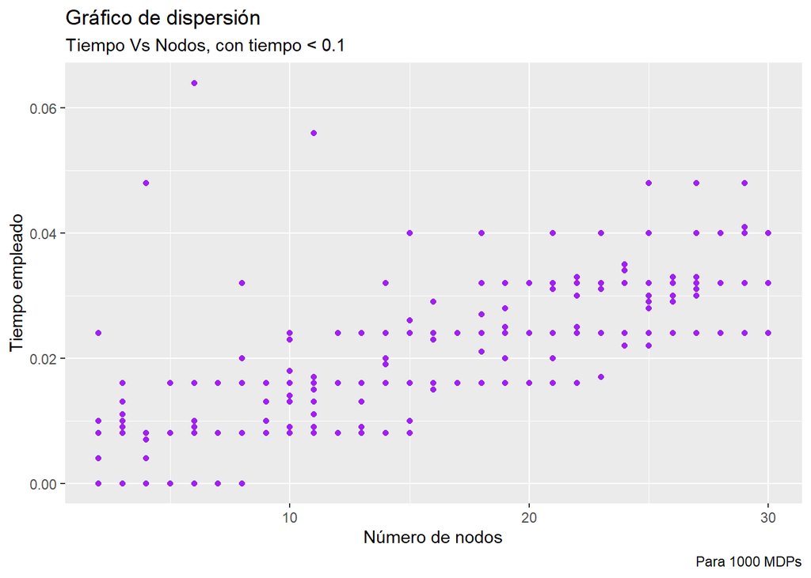

Una rápida observación a la tabla de resultados revela que estos *outliers* se encuentran en las primeras posiciones de la tabla, lo que podría explicar el funcionamiento atípico del programa dado que está generado el entorno de trabajo (la matriz de transición $T$ y la matriz de recompensas $R$) por primera vez para dicho número de nodos.

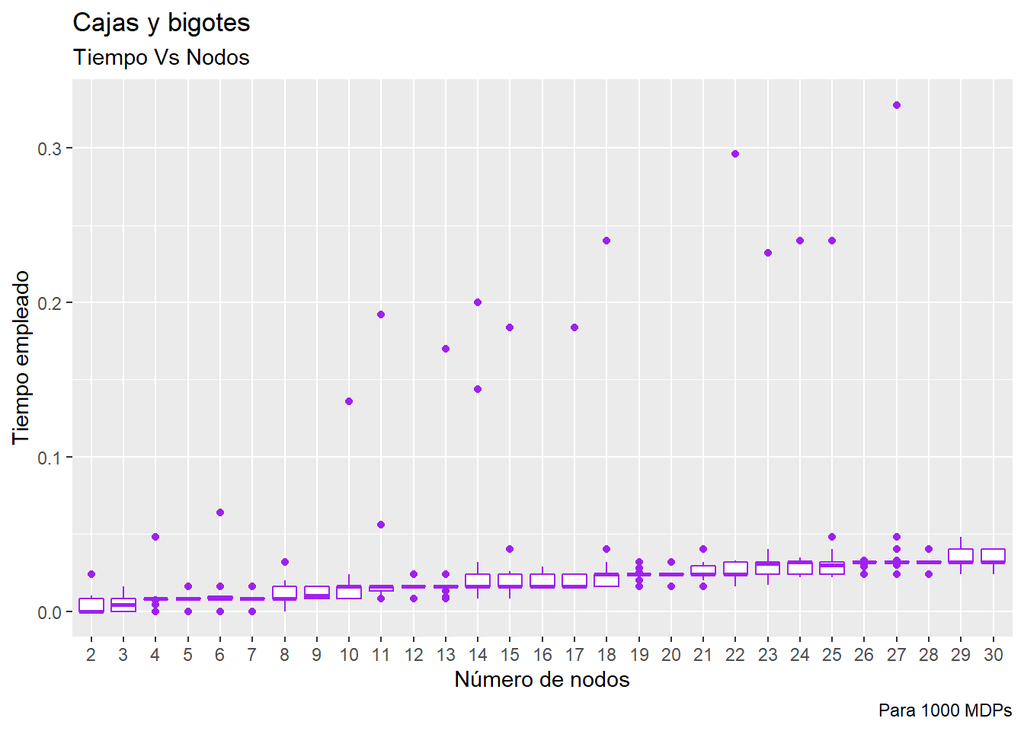

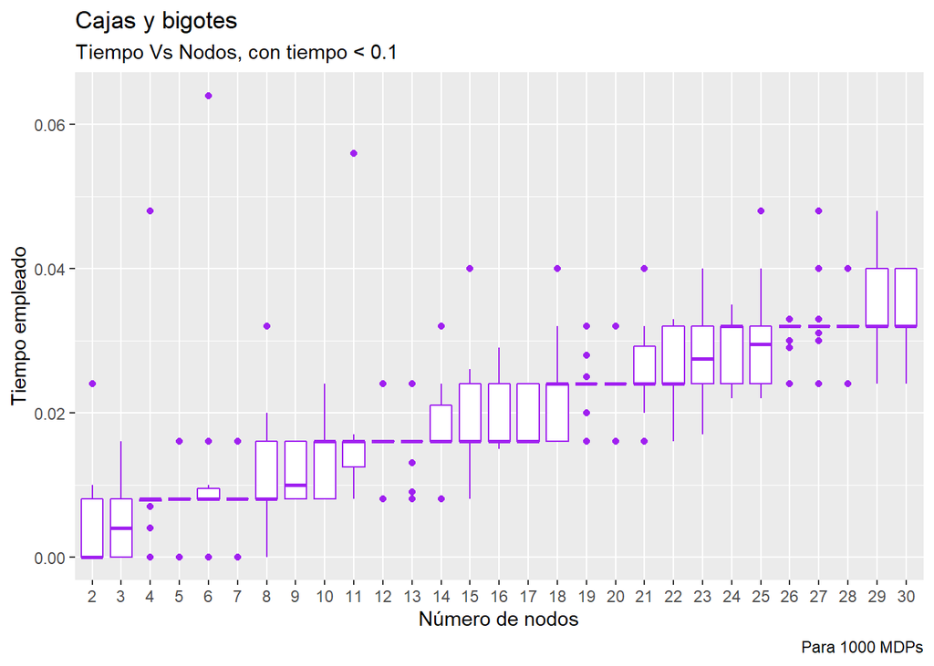

En general, parece que la solución implementada es relativamente rápida, no presentando demasiada variación entre problemas con semejante número de nodos. Es destacable que sería necesario llevar a cabo un análisis en mayor profundidad, estudiando, por ejemplo, de qué forma el número de acciones y de salidas por acción influyen en la velocidad de ejecución del algoritmo *Value-Iteration*, o los parámetros $\gamma$ y $\varepsilon$. Por otro lado, aprovechando la estructura ya definida, una forma de complementar el trabajo realizado sería definiendo el algoritmo *Q-Learning*, guardándolo con el formato ya indicado, pudiendo comparar los resultados según el algoritmo aplicado.

## Tema 3 - Breakout Distribuido

En esta sección nos centramos en la creación de un programa que aplique el algoritmo *Breakout Distribuido*, concretamente en el problema de la coloración de grafos. Incluimos aquí por comodidad la descripción de dicho algoritmo, extraído del Capítulo 3:

```r
  Modo wait_ok?
    Si se recibe ("Ok?", x_j, d_j) hacer:
        añadir (x_j, d_j) a agent_view
        Si se han recibido mensajes "Ok?" de todos los vecinos, hacer:
            enviar_improve
            entrar en Modo wait_improve
        entrar en Modo wait_ok?

  enviar_improve
    eval_actual ← evaluar valor de valor_actual
    mi_mejora ← posible máxima mejora
    nuevo_valor ← valor que da la máxima mejora
    enviar("improve", x_i, mi_mejora, eval_actual) a vecinos

  Modo wait_improve
    si se recibe ("improve", x_j, mejora, eval) hacer:
        grabar el mensaje
        Si se han recibido mensajes improve de todos los vecinos, hacer:
            enviar_ok
            limpiar agent_view
            entrar en Modo wait_ok
        entrar en Modo wait_improve

  enviar_ok
    Si su mejora es la mayor de los vecinos, hacer:
        valor_actual ← nuevo_valor
    Si es un cuasi-mínimo local, hacer:
        incrementa el peso de las restricciones violadas
    enviar ("Ok?", x_i, valor_actual) a los vecinos
```

### Archivos principales

Ej_Breakout_Distribuido.nlogo  
→ El algoritmo ya indicado, comentado y preparado para ejecutarse.

### Trabajo realizado

Aplicamos el algoritmo al problema de la coloración de grafos, generando con el programa un grafo con n-nodes nodos y admitiendo hasta n-colors colores.

La interfaz es como sigue:

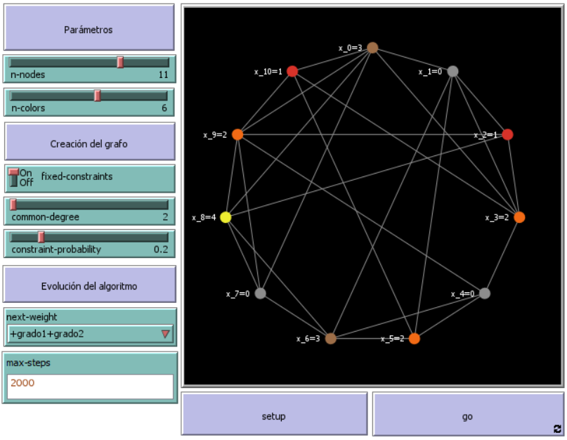

Con los siguientes parámetros:

| Parámetro | Uso |
| --- | --- |
| n-nodes | Número de nodos del grafo generado |
| n-colors | Número de colores disponibles |
| fixed-constraints? | Número fijo de restricciones o dependiente de constraint-probability? |
| common-degree | Grado esperado suponiendo fixed-constraints? |
| constraint-probability | Probabilidad de incluir una nueva restricción al construir el grafo |
| next-weight | Evolución de los pesos durante el algoritmo al encontra un cuasimímino. Con +1 se incrementa el valor en 1, y con +grado1+grado2 se incrementea en el valor de la suma de los grados de los nodos asocia… |
| max-steps | Número máximo de pasos antes de detener el algoritmo |

Para generar el grafo en cuestión se procede como sigue:

```r
  crea n-nodes nodos
  pide a los nodos sin restricciones {
    crea una restricción con el "siguiente" nodo
  }
  pide a los nodos {
    if (fixed-constraints) {
      repite tantas veces como common-degree {
        crea restricción con otro nodo
      }
    } else {
      repite tantas veces como n-nodes - 1 {
        crea restricción con otro nodo si random_num < constraint-probability
      }
    }
  }
```

En general obtendremos un grafo conexo, con una distribución de grados o bien constante o normal, por la forma en la que se crean las nuevas restricciones si fixed-constraints = FALSE.

Al aplicar el algoritmo *Breakout* Distribuido, podemos ver de qué forma este evoluciona, especialmente a la hora de resetear determinadas variables, gracias a una gráfica auxiliar, en la que podemos observar el valor asociado al peso de las restricciones violadas en cada paso del algoritmo. Una situación en la que el algoritmo para al encontrar una solución devolvería algo semejante a lo siguiente:

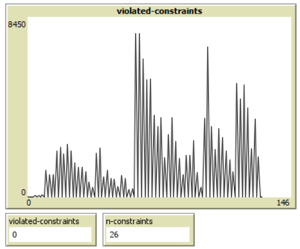

Nota: violated-constraints mide la suma de los pesos asociados a las restricciones violadas, y no el número de restricciones violadas.

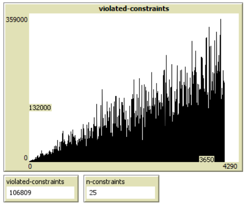

Una forma de ir más allá con este algoritmo sería almacenando la información generada, incluyendo el valor parámetro next-weight, con el objetivo de encontrar aquella evolución de los pesos que nos permita mejorar el comportamiento del algoritmo implementado.

Por otro lado, es destacable que la ejecución del algoritmo es bastante rápida para valores relativamente grandes de n-colors, pero se ralentiza considerablemente si lo reducimos, o si incrementamos el número de nodos involucrados, siendo necesaria alguna condición de parada, max-steps en nuestro caso.

## Temas 7 y 8.9. Aprendizaje y Reputación en el Dilema del Prisionero Iterado.

En esta sección nos centramos en la creación de un programa que incluya cuestiones sobre aprendizaje y reputación en el Dilema del Prisionero Iterado, recurriendo principalmente al planteamiento dado por Mui en 1 y a la primera aproximación considerada en cuanto a aprendizaje en el Capítulo 7. Destacamos que, aunque se hayan planteado las bases para preparar las diferentes implementaciones de la reputación de Mui, el algoritmo en dicho punto se encuentra incompleto, pudiendo crear agentes que tengan en cuenta la reputación, así como listas que representan las diferentes reputaciones, pero sin una herramienta que les permita a los agentes usar esta información directamente, más allá de la forma considerada en la sección de aprendizaje.

### Archivos principales

Prisionero_Iterado.nlogo  
→ El dilema del prisionero iterado con aprendizaje.

Para implementar este modelo hemos considerado la explicación proporcionada en el Capítulo 7, sobre aprendizaje, entendiendo que los diferentes agentes “recuerdan” su último encuentro con cada uno de los otros agentes. De esta forma, además de escoger si colaborar o delatar, es posible tomar esta decisión basándose en los anteriores encuentros, apareciendo nuevas estrategias como el “ojo por ojo”. Es importante destacar que, además, cada agente debe escoger si colaborar o no con otros agentes de los que no sabe nada aún. Estos diferentes comportamientos puedes resumirse con la siguiente tabla, basada en la de Mui 1:

| Nombre de la estrategia | Inicial | (D,C) | (C,C) | (C,D) | (D,D) |
| --- | --- | --- | --- | --- | --- |
| Coopera | C | C | C | C | C |
| Delata | D | D | D | D | D |
| Ojo por ojo | C | C | C | D | D |
| Ojo por ojo con reputación | * | C | C | D | D |

donde con D denotamos la acción “delatar”, y con C “cooperar”. El “ojo por ojo con reputación” difiere del “ojo por ojo” tradicional en que el agente coopera o delata dependiendo de la reputación que tiene del otro agente, dado que en el supuesto de la reputación puede obtener dicha información, ya sea a través de otros agentes, por observación directa o por cualesquiera otras vías.

### Trabajo realizado

Creamos el documento Prisionero_Iterado.nlogo, en el que se puede observar la siguiente interfaz básica:

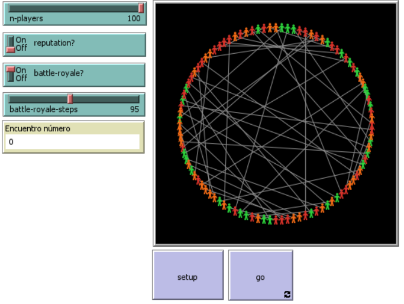

en la que podemos controlar el número de jugadores, así como el uso de reputación (no implementado completamente), y un parámetro llamado battle_royale?, que es el que activa la eliminación de los 2 jugadores con menos puntos cada battle-royale-steps. Este planteamiento evolutivo es semejante al considerado en muchas ocasiones para algoritmos genéticos, solo que en lugar de multiplicar las mejores estrategias eliminamos aquellas que proporcionan los perores resultados en un momento dado.

Como se puede ver en la imagen inferior, incluimos también como parámetros los asociados a las diferentes entradas de la matriz de pagos del juego, denotando por “D” al caso *defect*, en el que el agente delata/traiciona/deserta.

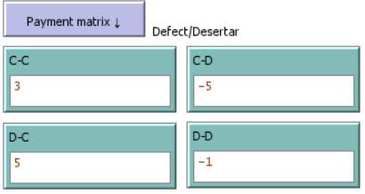

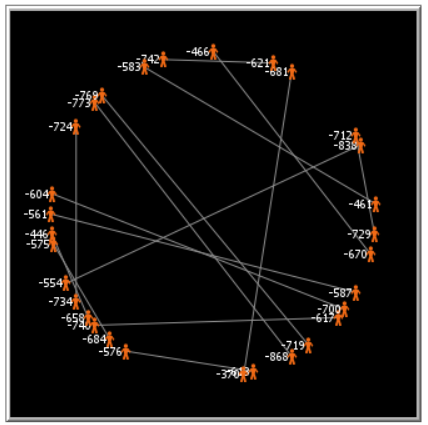

Con un valor de battle-royale-steps suficientemente grande es posible observar el comportamiento explicado por Mui en 1, en el que los agentes con la estrategia “ojo por ojo” (TFT) identifican a los que “siempre desertan” (D), no colaborando con ellos desde ese momento pero sí entre ellos mismos. De esta forma, a partir de cierto punto los TFT colaboran entre sí y mejoran su puntuación, mientras que los D se “destruyen” mutuamente al no colaborar. Una evolución habitual en este caso es la siguiente:

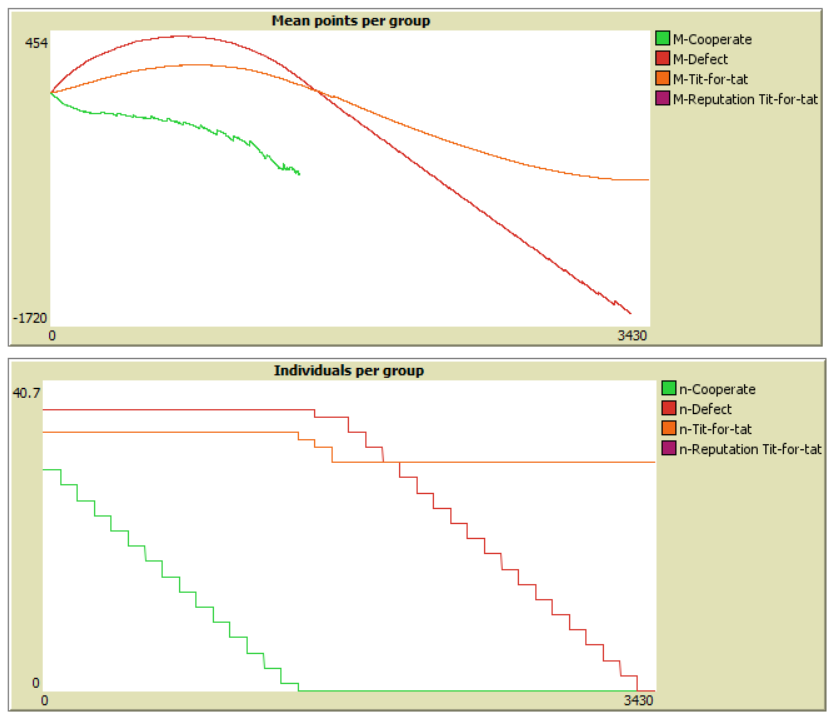

Adicionalmente, es claro ver que aquellos que “siempre colaboran” desaparecen con rapidez, eliminados como efecto de sus emparejamientos con los D. Por último, resulta interesante ver qué efecto tiene, por otro lado, reducir el parámetro battle-royale-steps, y es que como se puede ver en la siguiente imagen, el resultado habitual es la supervivencia del grupo D, dado que los TFT no aprenden lo suficientemente rápido como para identificar el comportamiento correcto a llevar a cabo con los D.

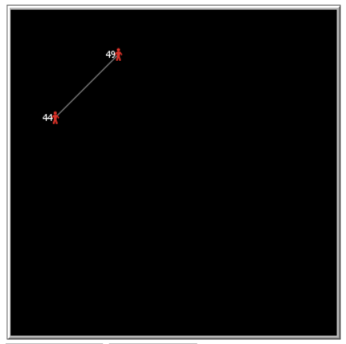

Como futuros pasos, sería interesante aprovechar la estructura planteada, ya con los parámetros sobre la reputación (listas de reputación, reputación pública, agentes con estrategia RTFT), e implementar uno o más de los modelos con reputación de Mui 1, considerando el caso en el que los agentes comparten información directamente, o aquel en el que la reputación de un agente es un valor público y observable por otros agentes. Adicionalmente, plantear el modelo suponiendo reproducción de las mejores estrategias en lugar de eliminación de las peores podría proporcionar resultados ligeramente diferentes, dado que podría darse que un incremento del número de agentes D al principio podría reducir considerablemente la esperanza de supervivencia de otros agentes. Otra alternativa sería considerar la eliminación de los agentes al llegar a cierta recompensa umbral, analizando los resultados según diferentes valores límite.

# Referencias

[0] - Sancho, F. (2022). Síntesis, Verificación y Razonamiento sobre Agentes Inteligentes, https://www.cs.us.es/~fsancho/Cursos/SVRAI. Consultado el 12/02/2022.  
[1] - Mui, Lik & Mohtashemi, Mojdeh & Halberstadt, Ari. (2002). Notions of reputation in multi-agents systems: A review. Proceedings of the International Conference on Autonomous Agents. 280-287. 10.1145/544741.544807